# Practicum 1

```r
# We have printed the column names and the rows which are outliers for the same. Apart from that, we have also printed the values of the outliers in a separate dataframe.
```

Problem 6: After removing the ID column (column 1), normalize the numeric columns, except the last one (the glass type), using z-score standardization. The last column is the glass type and so it is excluded.

```r
#Normalization of whole data excluding first and last column which are Id and Type column. We put it in a new dataframe called glass.norm

normalize <- function(x)
  {
    zscore <- (x - mean(x))/sd(x)
  }
glass.norm <- as.data.frame(lapply(glass.data[,2:10], normalize))

#We summarize the data and observe whether the data has been normalized or not.
summary(glass.norm)
```

```
##        RI                Na                Mg                Al
##  Min.   :-2.3759   Min.   :-3.2793   Min.   :-1.8611   Min.   :-2.3132
##  1st Qu.:-0.6068   1st Qu.:-0.6127   1st Qu.:-0.3948   1st Qu.:-0.5106
##  Median :-0.2257   Median :-0.1321   Median : 0.5515   Median :-0.1701
##  Mean   : 0.0000   Mean   : 0.0000   Mean   : 0.0000   Mean   : 0.0000
##  3rd Qu.: 0.2608   3rd Qu.: 0.5108   3rd Qu.: 0.6347   3rd Qu.: 0.3707
##  Max.   : 5.1252   Max.   : 4.8642   Max.   : 1.2517   Max.   : 4.1162
##        Si                K                  Ca                Ba
##  Min.   :-3.6679   Min.   :-0.76213   Min.   :-2.4783   Min.   :-0.3521
##  1st Qu.:-0.4789   1st Qu.:-0.57430   1st Qu.:-0.5038   1st Qu.:-0.3521
##  Median : 0.1795   Median : 0.08884   Median :-0.2508   Median :-0.3521
##  Mean   : 0.0000   Mean   : 0.00000   Mean   : 0.0000   Mean   : 0.0000
##  3rd Qu.: 0.5636   3rd Qu.: 0.17318   3rd Qu.: 0.1515   3rd Qu.:-0.3521
##  Max.   : 3.5622   Max.   : 8.75961   Max.   : 5.0824   Max.   : 5.9832
##        Fe
##  Min.   :-0.5851
##  1st Qu.:-0.5851
##  Median :-0.5851
##  Mean   : 0.0000
##  3rd Qu.: 0.4412
##  Max.   : 4.6490
```

```r
#Adding the last column back to the normalized data.
glass.norm$Type <- glass.data$Type

#Exploring normalized data
head(glass.norm)
```

|  | RI | Na | Mg | Al | Si | K | Ca | Ba | Fe | Type |
| --- | --- | --- | --- | --- | --- | --- | --- | --- | --- | --- |
| 1 | 0.8708258 | 0.2842867 | 1.2517037 | -0.6908222 | -1.12444556 | -0.67013422 | -0.1454254 | -0.3520514 | -0.5850791 | 1 |
| 2 | -0.2487502 | 0.5904328 | 0.6346799 | -0.1700615 | 0.10207972 | -0.02615193 | -0.7918771 | -0.3520514 | -0.5850791 | 1 |
| 3 | -0.7196308 | 0.1495824 | 0.6000157 | 0.1904651 | 0.43776033 | -0.16414813 | -0.8270103 | -0.3520514 | -0.5850791 | 1 |
| 4 | -0.2322859 | -0.2422846 | 0.6970756 | -0.3102663 | -0.05284979 | 0.11184428 | -0.5178378 | -0.3520514 | -0.5850791 | 1 |
| 5 | -0.3113148 | -0.1688095 | 0.6485456 | -0.4104126 | 0.55395746 | 0.08117845 | -0.6232375 | -0.3520514 | -0.5850791 | 1 |
| 6 | -0.7920739 | -0.7566101 | 0.6416128 | 0.3506992 | 0.41193874 | 0.21917466 | -0.6232375 | -0.3520514 | 2.0832652 | 1 |

Problem 7: The data set is sorted, so creating a validation data set requires random selection of elements. Create a stratified sample where you randomly select 20% of each of the cases for each glass type to be part of the validation data set. The remaining cases will form the training data set.

```r
#Setting the seed value to 1 for random allocation of data
set.seed(1)

library(caret)
library(dplyr)

#Checking total number of rows for each case of type
glass.norm %>% group_by(Type) %>% summarise(rows = length(Type))
```

| Type | rows |
| --- | --- |
| 1 | 70 |
| 2 | 76 |
| 3 | 17 |
| 5 | 13 |
| 6 | 9 |
| 7 | 29 |

```r
#Splitting data using createDataPartition function with a probabilty of 20% for validation data.
index <- createDataPartition(glass.norm$Type, p = 0.2, list = FALSE)
training_data <- glass.norm[-index,]
validation_data <- glass.norm[index,]

#Verifying validation data
validation_data %>% group_by(Type) %>% summarise(rows = length(Type))
```

| Type | rows |
| --- | --- |
| 1 | 15 |
| 2 | 15 |
| 3 | 4 |
| 5 | 2 |
| 6 | 1 |
| 7 | 8 |

```r
#Creating label vector for training and validation data
training_data_label <- training_data[,10]
validation_data_label <- validation_data[,10]
```

Problem 8: Implement the k-NN algorithm in R (do not use an implementation of k-NN from a package) and use your algorithm with a k=5 to predict the glass type for the following two cases: RI = 1.51621 | 12.53 | 3.48 | 1.39 | 73.39 | 0.60 | 8.55 | 0.00 | Fe = 0.08 RI = 1.5893 | 12.71 | 1.85 | 1.82 | 72.62 | 0.52 | 10.51 | 0.00 | Fe = 0.05 Use the whole normalized data set for this; not just the training data set. Note that you need to normalize the values of the new cases the same way as you normalized the original data.

```r
#Implementation of kNN algorithm
data.knn <- glass.norm
data <- glass.data[-1]

#Creating unknown case variables and assigning the values to it
unknown1 <- as.data.frame(cbind(1.51621,12.53,3.48,1.39,73.39,0.6,8.55,0.00,0.08))
unknown2 <- as.data.frame(cbind(1.5893,12.71,1.85,1.82,72.62,0.52,10.51,0.00,0.05))

#Normalizing the new test cases using z-score method which was used earlier
for (i in 1:9)
  {
    unknown1[i] <- (unknown1[i]-mean(data[,i]))/sd(data[,i])
    unknown2[i] <- (unknown2[i]-mean(data[,i]))/sd(data[,i])
  }

#Creating a distance function to calculate the euclidean distance
distance <- function(x,y)
  {
    d <- 0
    for (i in 1:length(x))
      {
        d <- d + (x[i]-y[i])^2
      }
    return(sqrt(d))
  }

#Neighbours function to a list of neighbours
neighbours <- function(train,unknown)
  {
    m <- nrow(train)
    k <- nrow(unknown)
    ds <- numeric(m)
    for (i in 1:m) {
      p <- train[i,1:9]
      q <- unknown[c(1:9)]
      ds[i] <- distance(p,q)
    }
    return(unlist(ds))
  }

#k.closest function is used to select k nearest neighbours by using order function
k.closest <- function(neighbours,k)
  {
    ordered.neighbours <- order(neighbours)
    return(ordered.neighbours[1:k])
  }

#Mode function used to calculate mode
Mode <- function(x)
  {
    ux <- unique(x)
    ux[which.max(tabulate(match(x,ux)))]
  }

#kNN Implementation
knn_new <- function(train,unknown,k)
  {
    neighbour <- neighbours(train, unknown)
    closest_neighbours <- k.closest(neighbour, k)
    return(Mode(data.knn$Type[closest_neighbours]))
  }

#Predicting values for both test cases with K=5 value
test1 <- knn_new(data.knn,unknown1,5)
sprintf("Predicted glass type for unknown case one is %s", test1)
```

```
## [1] "Predicted glass type for unknown case one is 1"
```

```r
test2 <- knn_new(data.knn,unknown2,5)
sprintf("Predicted glass type for unknown case two is %s", test2)
```

```
## [1] "Predicted glass type for unknown case two is 2"
```

Problem 9: Apply the knn function from the class package with k=5 and redo the cases from Question (8). Compare your answers.

```r
#Implementation of kNN algorithm using Class package
library(class)

test_class1 <- knn(train = data.knn[,1:9],test = unknown1,cl = data.knn[,10],k=5)
sprintf("Predicted glass type for unknown case one using class package is %s", test_class1)
```

```
## [1] "Predicted glass type for unknown case one using class package is 1"
```

```r
test_class2 <- knn(train = data.knn[,1:9],test = unknown2,cl = data.knn[,10],k=5)
sprintf("Predicted glass type for unknown case two using class package is %s", test_class2)
```

```
## [1] "Predicted glass type for unknown case two using class package is 2"
```

```r
#After predicting both cases with two implementation we get same result with both implementation i.e Predicted value as 1 & 2.
```

Problem 10: Using your own implementation as well as the class package implementation of kNN, create a plot of k (x-axis) from 2 to 10 versus error rate (percentage of incorrect classifications) for both algorithms using ggplot.

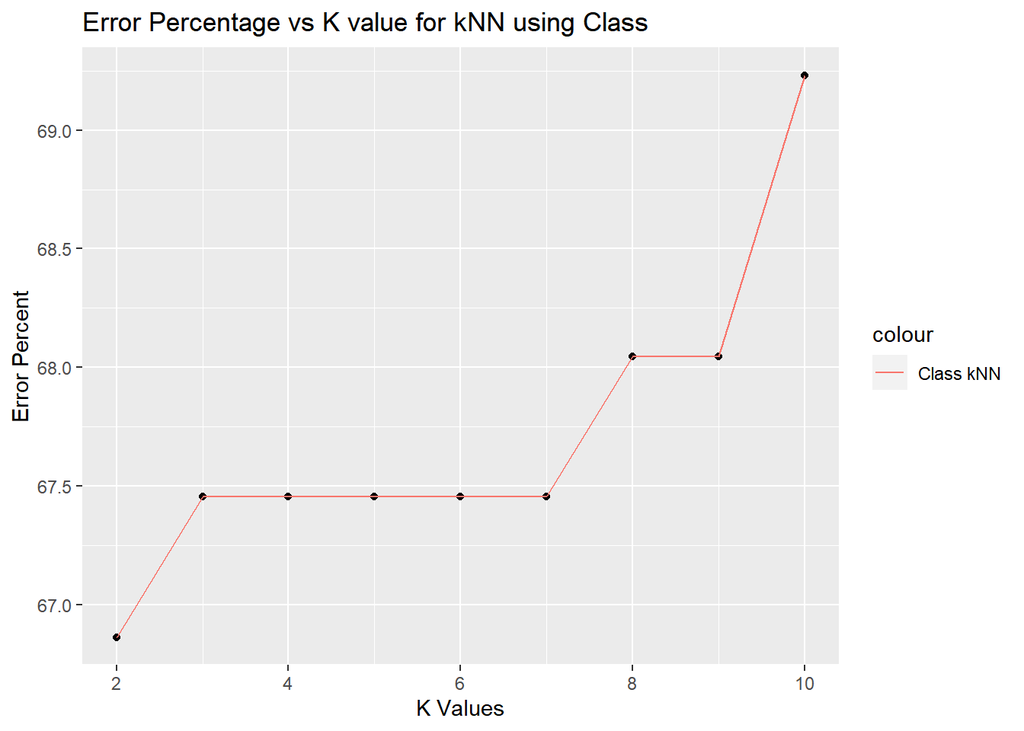

```r
#Error plot
#install.packages("ggplot2")
library(ggplot2)

#Calculating error percentage Using Class implementation
train_error_pred <- rep(0,nrow(training_data))
error <- data.frame(n=c(2:10),perc = rep(NA,9))

for (i in 2:10) {
  train_error_pred <- knn(training_data, validation_data, training_data_label, i)
  error[i-1,2] <- (sum(training_data_label != train_error_pred)/nrow(training_data))*100
}
#Plotting Error percentage vs k-Values using ggplot function for class package
ggplot(error, aes(x = error[,1], y = error[,2]))+geom_point()+geom_line(aes(color = "Class kNN"))+xlab("K Values")+ylab("Error Percent")+ggtitle("Error Percentage vs K value for kNN using Class")
```

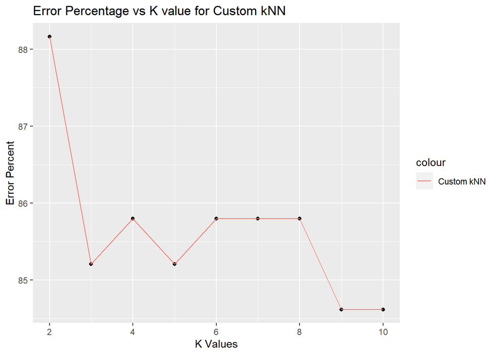

```r
#Error using kNN.reg Implementation
train_error_pred <- rep(0,nrow(training_data))
error_new <- data.frame(n=c(2:10),perc = rep(NA,9))

#Defining kNN.reg function as newKnn
newKnn <- function(train,x,k)
{
  dist <- rep(NA, nrow(train))
for (i in 1:nrow(train))
  {
  # Calculating euclidean distance
  dist[i] <- sqrt(sum((train[i,1:9] - glass.norm[x, 1:9])^2))
  }
  o <- order(dist)
  closest <- glass.norm$Type[o[1:k]]
  return(Mode(closest))
}

val_rows <- as.integer(rownames(validation_data))
for (i in 2:10){
  for (j in 1:nrow(validation_data)){
    train_error_pred[j] <- newKnn(training_data,val_rows[j],i)
  }
error_new[i-1,2] <- sum(training_data_label != train_error_pred) / nrow(training_data) * 100
}

#Plotting Error percentage vs k-Values using ggplot function for kNN.reg implementation
ggplot(error_new, aes(x = error_new[,1], y = error_new[,2]))+geom_point()+geom_line(aes(color = "Custom kNN"))+xlab("K Values")+ylab("Error Percent")+ggtitle("Error Percentage vs K value for Custom kNN")
```

Problem 11: Produce a cross-table confusion matrix showing the accuracy of the classification using knn from the class package with k = 5.

```r
#Calling gmodels library to use crosstable function

#install.packages("gmodels")
#install.packages("caret")
#install.packages("e1071")
library(class)
library(caret)
library(e1071)
library(gmodels)

#Running knn function from class package for training and validation data with k = 5
train_pred <- knn(train = training_data, test = validation_data, cl = training_data_label, k = 5)

#Producing CrossTable and Confusion matrix for the classification
CrossTable(x = validation_data_label, y = train_pred, prop.chisq = FALSE)
```

```
##
##
##    Cell Contents
## |-------------------------|
## |                       N |
## |           N / Row Total |
## |           N / Col Total |
## |         N / Table Total |
## |-------------------------|
##
##
## Total Observations in Table:  45
##
##
##                       | train_pred
## validation_data_label |         1 |         2 |         3 |         5 |         6 |         7 | Row Total |
## ----------------------|-----------|-----------|-----------|-----------|-----------|-----------|-----------|
##                     1 |        15 |         0 |         0 |         0 |         0 |         0 |        15 |
##                       |     1.000 |     0.000 |     0.000 |     0.000 |     0.000 |     0.000 |     0.333 |
##                       |     0.833 |     0.000 |     0.000 |     0.000 |     0.000 |     0.000 |           |
##                       |     0.333 |     0.000 |     0.000 |     0.000 |     0.000 |     0.000 |           |
## ----------------------|-----------|-----------|-----------|-----------|-----------|-----------|-----------|
##                     2 |         1 |        14 |         0 |         0 |         0 |         0 |        15 |
##                       |     0.067 |     0.933 |     0.000 |     0.000 |     0.000 |     0.000 |     0.333 |
##                       |     0.056 |     1.000 |     0.000 |     0.000 |     0.000 |     0.000 |           |
##                       |     0.022 |     0.311 |     0.000 |     0.000 |     0.000 |     0.000 |           |
## ----------------------|-----------|-----------|-----------|-----------|-----------|-----------|-----------|
##                     3 |         2 |         0 |         2 |         0 |         0 |         0 |         4 |
##                       |     0.500 |     0.000 |     0.500 |     0.000 |     0.000 |     0.000 |     0.089 |
##                       |     0.111 |     0.000 |     1.000 |     0.000 |     0.000 |     0.000 |           |
##                       |     0.044 |     0.000 |     0.044 |     0.000 |     0.000 |     0.000 |           |
## ----------------------|-----------|-----------|-----------|-----------|-----------|-----------|-----------|
##                     5 |         0 |         0 |         0 |         2 |         0 |         0 |         2 |
##                       |     0.000 |     0.000 |     0.000 |     1.000 |     0.000 |     0.000 |     0.044 |
##                       |     0.000 |     0.000 |     0.000 |     0.667 |     0.000 |     0.000 |           |
##                       |     0.000 |     0.000 |     0.000 |     0.044 |     0.000 |     0.000 |           |
## ----------------------|-----------|-----------|-----------|-----------|-----------|-----------|-----------|
##                     6 |         0 |         0 |         0 |         0 |         1 |         0 |         1 |
##                       |     0.000 |     0.000 |     0.000 |     0.000 |     1.000 |     0.000 |     0.022 |
##                       |     0.000 |     0.000 |     0.000 |     0.000 |     0.500 |     0.000 |           |
##                       |     0.000 |     0.000 |     0.000 |     0.000 |     0.022 |     0.000 |           |
## ----------------------|-----------|-----------|-----------|-----------|-----------|-----------|-----------|
##                     7 |         0 |         0 |         0 |         1 |         1 |         6 |         8 |
##                       |     0.000 |     0.000 |     0.000 |     0.125 |     0.125 |     0.750 |     0.178 |
##                       |     0.000 |     0.000 |     0.000 |     0.333 |     0.500 |     1.000 |           |
##                       |     0.000 |     0.000 |     0.000 |     0.022 |     0.022 |     0.133 |           |
## ----------------------|-----------|-----------|-----------|-----------|-----------|-----------|-----------|
##          Column Total |        18 |        14 |         2 |         3 |         2 |         6 |        45 |
##                       |     0.400 |     0.311 |     0.044 |     0.067 |     0.044 |     0.133 |           |
## ----------------------|-----------|-----------|-----------|-----------|-----------|-----------|-----------|
##
##
```

```r
confusionMatrix(train_pred,as.factor(validation_data_label))
```

```
## Confusion Matrix and Statistics
##
##           Reference
## Prediction  1  2  3  5  6  7
##          1 15  1  2  0  0  0
##          2  0 14  0  0  0  0
##          3  0  0  2  0  0  0
##          5  0  0  0  2  0  1
##          6  0  0  0  0  1  1
##          7  0  0  0  0  0  6
##
## Overall Statistics
##
##                Accuracy : 0.8889
##                  95% CI : (0.7595, 0.9629)
##     No Information Rate : 0.3333
##     P-Value [Acc > NIR] : 1.408e-14
##
##                   Kappa : 0.8481
##
##  Mcnemar's Test P-Value : NA
##
## Statistics by Class:
##
##                      Class: 1 Class: 2 Class: 3 Class: 5 Class: 6 Class: 7
## Sensitivity            1.0000   0.9333  0.50000  1.00000  1.00000   0.7500
## Specificity            0.9000   1.0000  1.00000  0.97674  0.97727   1.0000
## Pos Pred Value         0.8333   1.0000  1.00000  0.66667  0.50000   1.0000
## Neg Pred Value         1.0000   0.9677  0.95349  1.00000  1.00000   0.9487
## Prevalence             0.3333   0.3333  0.08889  0.04444  0.02222   0.1778
## Detection Rate         0.3333   0.3111  0.04444  0.04444  0.02222   0.1333
## Detection Prevalence   0.4000   0.3111  0.04444  0.06667  0.04444   0.1333
## Balanced Accuracy      0.9500   0.9667  0.75000  0.98837  0.98864   0.8750
```

```r
#We observe the accurary for model in the confusion matrix. Accuracy varies for different seed value. For seed = 1 we get accuracy as 88.8%, for seed = 101, we get accuracy of 95.6%
```

Problem 12: Download this (modified) version of the Glass data set containing missing values in column 4. Identify the missing values. Impute the missing values using your version of kNN from Problem 2 below using the other columns are predictor features.

```r
#Importing new modified data using read.csv function

missing_glass_data <- read.csv("https://da5030.weebly.com/uploads/8/6/5/9/8659576/da5030.glass.data_with_missing_values.csv", stringsAsFactors = F, header = F)

#Assigning header to the data
colnames(missing_glass_data) <- col_names

#Checking for NA's in the data. We observe that "Mg" column has 9 NA Values
summary(missing_glass_data)
```

```
##        Id               RI              Na              Mg
##  Min.   :  1.00   Min.   :1.511   Min.   :10.73   Min.   :0.000
##  1st Qu.: 54.25   1st Qu.:1.517   1st Qu.:12.91   1st Qu.:2.240
##  Median :107.50   Median :1.518   Median :13.30   Median :3.480
##  Mean   :107.50   Mean   :1.518   Mean   :13.41   Mean   :2.733
##  3rd Qu.:160.75   3rd Qu.:1.519   3rd Qu.:13.82   3rd Qu.:3.610
##  Max.   :214.00   Max.   :1.534   Max.   :17.38   Max.   :4.490
##                                                   NA's   :9
##        Al              Si              K                Ca
##  Min.   :0.290   Min.   :69.81   Min.   :0.0000   Min.   : 5.430
##  1st Qu.:1.190   1st Qu.:72.28   1st Qu.:0.1225   1st Qu.: 8.240
##  Median :1.360   Median :72.79   Median :0.5550   Median : 8.600
##  Mean   :1.445   Mean   :72.65   Mean   :0.4971   Mean   : 8.957
##  3rd Qu.:1.630   3rd Qu.:73.09   3rd Qu.:0.6100   3rd Qu.: 9.172
##  Max.   :3.500   Max.   :75.41   Max.   :6.2100   Max.   :16.190
##
##        Ba              Fe               Type
##  Min.   :0.000   Min.   :0.00000   Min.   :1.00
##  1st Qu.:0.000   1st Qu.:0.00000   1st Qu.:1.00
##  Median :0.000   Median :0.00000   Median :2.00
##  Mean   :0.175   Mean   :0.05701   Mean   :2.78
##  3rd Qu.:0.000   3rd Qu.:0.10000   3rd Qu.:3.00
##  Max.   :3.150   Max.   :0.51000   Max.   :7.00
##
```

```r
#Removing Id column
missing_glass_data <- missing_glass_data[-1]

col_list <- c(1,2,4,5,6,7,8,9)

normalized_data <- missing_glass_data

#Normalizing the new data with min-max normalization method
for (i in col_list)
  {
    normalized_data[,i] <- (missing_glass_data[,i]-min(missing_glass_data[,i]))/(max(missing_glass_data[,i])-min(missing_glass_data[,i]))
  }

#We create new forecast variable for each NA row. Since we have 9 NA rows we create 9 vectors
forecast_data.1 <- normalized_data[20,c(1,2,4,5,6,7,8,9,10)]
forecast_data.2 <- normalized_data[30,c(1,2,4,5,6,7,8,9,10)]
forecast_data.3 <- normalized_data[95,c(1,2,4,5,6,7,8,9,10)]
forecast_data.4 <- normalized_data[163,c(1,2,4,5,6,7,8,9,10)]
forecast_data.5 <- normalized_data[169,c(1,2,4,5,6,7,8,9,10)]
forecast_data.6 <- normalized_data[184,c(1,2,4,5,6,7,8,9,10)]
forecast_data.7 <- normalized_data[194,c(1,2,4,5,6,7,8,9,10)]
forecast_data.8 <- normalized_data[200,c(1,2,4,5,6,7,8,9,10)]
forecast_data.9 <- normalized_data[208,c(1,2,4,5,6,7,8,9,10)]

missing_data <- normalized_data[-c(20,30,95,163,169,184,194,200,208),]

#Creating training and target data of the new modified data
train_data_new <- missing_data[,c(1,2,4,5,6,7,8,9,10)]
target_data_new <- missing_data[,3]

#kNN.reg function from problem 2
kNN.reg <- function(new_data, target_data, train_data, k){
  weights <- numeric(k)
  n <- nrow(train_data)
  d <- rep(0,n)
  for (i in 1:n)
  {
    d[i] <- sqrt(sum((train_data[i,] - new_data)^2))
  }
  o <- order(d)
  values <- target_data[o[1:k]]
  weights <- c(3,2)
  for (i in 3:k)
  {
    weights[i] <- 1
  }
  sw <- values * weights
  return(sum(sw)/sum(weights))
}

#Calling kNN.reg function from problem 2 to get predicted values
impute_forecast.1 <- kNN.reg(forecast_data.1, target_data_new, train_data_new, 4)
impute_forecast.2 <- kNN.reg(forecast_data.2, target_data_new, train_data_new, 4)
impute_forecast.3 <- kNN.reg(forecast_data.3, target_data_new, train_data_new, 4)
impute_forecast.4 <- kNN.reg(forecast_data.4, target_data_new, train_data_new, 4)
impute_forecast.5 <- kNN.reg(forecast_data.5, target_data_new, train_data_new, 4)
impute_forecast.6 <- kNN.reg(forecast_data.6, target_data_new, train_data_new, 4)
impute_forecast.7 <- kNN.reg(forecast_data.7, target_data_new, train_data_new, 4)
impute_forecast.8 <- kNN.reg(forecast_data.8, target_data_new, train_data_new, 4)
impute_forecast.9 <- kNN.reg(forecast_data.9, target_data_new, train_data_new, 4)

impute_forecast <- rbind(impute_forecast.1,impute_forecast.2,impute_forecast.3,impute_forecast.4,impute_forecast.5,impute_forecast.6,impute_forecast.7,impute_forecast.8,impute_forecast.9)

#We can observe the imputed values in a dataframe for the Mg column
rownames(impute_forecast) <- c(20,30,95,163,169,184,194,200,208)
colnames(impute_forecast) <- "Mg"
print("Imputed Values for the Mg Column:")
```

```
## [1] "Imputed Values for the Mg Column:"
```

```r
impute_forecast
```

```
##            Mg
## 20  3.3385714
## 30  3.4842857
## 95  3.5114286
## 163 3.4928571
## 169 0.7971429
## 184 2.3485714
## 194 0.0000000
## 200 0.0000000
## 208 0.4657143
```

```r
#Appending the imputed values to main dataset which is missing_glass_data
missing_glass_data[c(20,30,95,163,169,184,194,200,208),3] <- c(impute_forecast.1,impute_forecast.2,impute_forecast.3,impute_forecast.4,impute_forecast.5,impute_forecast.6,impute_forecast.7,impute_forecast.8,impute_forecast.9)

#Verifying whether NA values are imputed or not
summary(missing_glass_data)
```

```
##        RI              Na              Mg              Al
##  Min.   :1.511   Min.   :10.73   Min.   :0.000   Min.   :0.290
##  1st Qu.:1.517   1st Qu.:12.91   1st Qu.:2.192   1st Qu.:1.190
##  Median :1.518   Median :13.30   Median :3.480   Median :1.360
##  Mean   :1.518   Mean   :13.41   Mean   :2.700   Mean   :1.445
##  3rd Qu.:1.519   3rd Qu.:13.82   3rd Qu.:3.600   3rd Qu.:1.630
##  Max.   :1.534   Max.   :17.38   Max.   :4.490   Max.   :3.500
##        Si              K                Ca               Ba
##  Min.   :69.81   Min.   :0.0000   Min.   : 5.430   Min.   :0.000
##  1st Qu.:72.28   1st Qu.:0.1225   1st Qu.: 8.240   1st Qu.:0.000
##  Median :72.79   Median :0.5550   Median : 8.600   Median :0.000
##  Mean   :72.65   Mean   :0.4971   Mean   : 8.957   Mean   :0.175
##  3rd Qu.:73.09   3rd Qu.:0.6100   3rd Qu.: 9.172   3rd Qu.:0.000
##  Max.   :75.41   Max.   :6.2100   Max.   :16.190   Max.   :3.150
##        Fe               Type
##  Min.   :0.00000   Min.   :1.00
##  1st Qu.:0.00000   1st Qu.:1.00
##  Median :0.00000   Median :2.00
##  Mean   :0.05701   Mean   :2.78
##  3rd Qu.:0.10000   3rd Qu.:3.00
##  Max.   :0.51000   Max.   :7.00
```

```
                                                  --- Question 2 ---
```

Problem 1: Investigate this data set of home prices in King County (USA).

```r
#Importing house data using read.csv
house.data <- read.csv("D:\\Northeastern\\DM & ML\\Practicum 1\\kc_house_data.csv", stringsAsFactors = F, header = T)

#Exploring house data and studying the data types present in it
head(house.data)
```

|  | id | date | price | bedrooms | bathrooms | sqft_living | sqft_lot | floors | waterfront | view | condition | grade | sqft_above | sqft_basement | yr_built | yr_renovated | zipcode | lat | long | sqft_living15 | sqft_lot15 |
| --- | --- | --- | --- | --- | --- | --- | --- | --- | --- | --- | --- | --- | --- | --- | --- | --- | --- | --- | --- | --- | --- |
| 1 | 7129300520 | 20141013T000000 | 221900 | 3 | 1.00 | 1180 | 5650 | 1 | 0 | 0 | 3 | 7 | 1180 | 0 | 1955 | 0 | 98178 | 47.5112 | -122.257 | 1340 | 5650 |
| 2 | 6414100192 | 20141209T000000 | 538000 | 3 | 2.25 | 2570 | 7242 | 2 | 0 | 0 | 3 | 7 | 2170 | 400 | 1951 | 1991 | 98125 | 47.7210 | -122.319 | 1690 | 7639 |
| 3 | 5631500400 | 20150225T000000 | 180000 | 2 | 1.00 | 770 | 10000 | 1 | 0 | 0 | 3 | 6 | 770 | 0 | 1933 | 0 | 98028 | 47.7379 | -122.233 | 2720 | 8062 |
| 4 | 2487200875 | 20141209T000000 | 604000 | 4 | 3.00 | 1960 | 5000 | 1 | 0 | 0 | 5 | 7 | 1050 | 910 | 1965 | 0 | 98136 | 47.5208 | -122.393 | 1360 | 5000 |
| 5 | 1954400510 | 20150218T000000 | 510000 | 3 | 2.00 | 1680 | 8080 | 1 | 0 | 0 | 3 | 8 | 1680 | 0 | 1987 | 0 | 98074 | 47.6168 | -122.045 | 1800 | 7503 |
| 6 | 7237550310 | 20140512T000000 | 1225000 | 4 | 4.50 | 5420 | 101930 | 1 | 0 | 0 | 3 | 11 | 3890 | 1530 | 2001 | 0 | 98053 | 47.6561 | -122.005 | 4760 | 101930 |

```r
str(house.data)
```

```
## 'data.frame':    21613 obs. of  21 variables:
##  $ id           : num  7.13e+09 6.41e+09 5.63e+09 2.49e+09 1.95e+09 ...
##  $ date         : chr  "20141013T000000" "20141209T000000" "20150225T000000" "20141209T000000" ...
##  $ price        : num  221900 538000 180000 604000 510000 ...
##  $ bedrooms     : int  3 3 2 4 3 4 3 3 3 3 ...
##  $ bathrooms    : num  1 2.25 1 3 2 4.5 2.25 1.5 1 2.5 ...
##  $ sqft_living  : int  1180 2570 770 1960 1680 5420 1715 1060 1780 1890 ...
##  $ sqft_lot     : int  5650 7242 10000 5000 8080 101930 6819 9711 7470 6560 ...
##  $ floors       : num  1 2 1 1 1 1 2 1 1 2 ...
##  $ waterfront   : int  0 0 0 0 0 0 0 0 0 0 ...
##  $ view         : int  0 0 0 0 0 0 0 0 0 0 ...
##  $ condition    : int  3 3 3 5 3 3 3 3 3 3 ...
##  $ grade        : int  7 7 6 7 8 11 7 7 7 7 ...
##  $ sqft_above   : int  1180 2170 770 1050 1680 3890 1715 1060 1050 1890 ...
##  $ sqft_basement: int  0 400 0 910 0 1530 0 0 730 0 ...
##  $ yr_built     : int  1955 1951 1933 1965 1987 2001 1995 1963 1960 2003 ...
##  $ yr_renovated : int  0 1991 0 0 0 0 0 0 0 0 ...
##  $ zipcode      : int  98178 98125 98028 98136 98074 98053 98003 98198 98146 98038 ...
##  $ lat          : num  47.5 47.7 47.7 47.5 47.6 ...
##  $ long         : num  -122 -122 -122 -122 -122 ...
##  $ sqft_living15: int  1340 1690 2720 1360 1800 4760 2238 1650 1780 2390 ...
##  $ sqft_lot15   : int  5650 7639 8062 5000 7503 101930 6819 9711 8113 7570 ...
```

```r
summary(house.data)
```

```
##        id                date               price            bedrooms
##  Min.   :1.000e+06   Length:21613       Min.   :  75000   Min.   : 0.000
##  1st Qu.:2.123e+09   Class :character   1st Qu.: 321950   1st Qu.: 3.000
##  Median :3.905e+09   Mode  :character   Median : 450000   Median : 3.000
##  Mean   :4.580e+09                      Mean   : 540088   Mean   : 3.371
##  3rd Qu.:7.309e+09                      3rd Qu.: 645000   3rd Qu.: 4.000
##  Max.   :9.900e+09                      Max.   :7700000   Max.   :33.000
##    bathrooms      sqft_living       sqft_lot           floors
##  Min.   :0.000   Min.   :  290   Min.   :    520   Min.   :1.000
##  1st Qu.:1.750   1st Qu.: 1427   1st Qu.:   5040   1st Qu.:1.000
##  Median :2.250   Median : 1910   Median :   7618   Median :1.500
##  Mean   :2.115   Mean   : 2080   Mean   :  15107   Mean   :1.494
##  3rd Qu.:2.500   3rd Qu.: 2550   3rd Qu.:  10688   3rd Qu.:2.000
##  Max.   :8.000   Max.   :13540   Max.   :1651359   Max.   :3.500
##    waterfront            view          condition         grade
##  Min.   :0.000000   Min.   :0.0000   Min.   :1.000   Min.   : 1.000
##  1st Qu.:0.000000   1st Qu.:0.0000   1st Qu.:3.000   1st Qu.: 7.000
##  Median :0.000000   Median :0.0000   Median :3.000   Median : 7.000
##  Mean   :0.007542   Mean   :0.2343   Mean   :3.409   Mean   : 7.657
##  3rd Qu.:0.000000   3rd Qu.:0.0000   3rd Qu.:4.000   3rd Qu.: 8.000
##  Max.   :1.000000   Max.   :4.0000   Max.   :5.000   Max.   :13.000
##    sqft_above   sqft_basement       yr_built     yr_renovated
##  Min.   : 290   Min.   :   0.0   Min.   :1900   Min.   :   0.0
##  1st Qu.:1190   1st Qu.:   0.0   1st Qu.:1951   1st Qu.:   0.0
##  Median :1560   Median :   0.0   Median :1975   Median :   0.0
##  Mean   :1788   Mean   : 291.5   Mean   :1971   Mean   :  84.4
##  3rd Qu.:2210   3rd Qu.: 560.0   3rd Qu.:1997   3rd Qu.:   0.0
##  Max.   :9410   Max.   :4820.0   Max.   :2015   Max.   :2015.0
##     zipcode           lat             long        sqft_living15
##  Min.   :98001   Min.   :47.16   Min.   :-122.5   Min.   : 399
##  1st Qu.:98033   1st Qu.:47.47   1st Qu.:-122.3   1st Qu.:1490
##  Median :98065   Median :47.57   Median :-122.2   Median :1840
##  Mean   :98078   Mean   :47.56   Mean   :-122.2   Mean   :1987
##  3rd Qu.:98118   3rd Qu.:47.68   3rd Qu.:-122.1   3rd Qu.:2360
##  Max.   :98199   Max.   :47.78   Max.   :-121.3   Max.   :6210
##    sqft_lot15
##  Min.   :   651
##  1st Qu.:  5100
##  Median :  7620
##  Mean   : 12768
##  3rd Qu.: 10083
##  Max.   :871200
```

Problem 2: Save the price column in a separate vector/dataframe called target_data. Move all of the columns except the ID, date, price, yr_renovated, zipcode, lat, long, sqft_living15, and sqft_lot15 columns into a new data frame called train_data.

```r
#Create Target Data which contains price column
target_data <- house.data$price
head(target_data)
```

```
## [1]  221900  538000  180000  604000  510000 1225000
```

```r
#Moving other columns to train_data which are used for training the model
train_data <- house.data[,4:15]
head(train_data)
```

|  | bedrooms | bathrooms | sqft_living | sqft_lot | floors | waterfront | view | condition | grade | sqft_above | sqft_basement | yr_built |
| --- | --- | --- | --- | --- | --- | --- | --- | --- | --- | --- | --- | --- |
| 1 | 3 | 1.00 | 1180 | 5650 | 1 | 0 | 0 | 3 | 7 | 1180 | 0 | 1955 |
| 2 | 3 | 2.25 | 2570 | 7242 | 2 | 0 | 0 | 3 | 7 | 2170 | 400 | 1951 |
| 3 | 2 | 1.00 | 770 | 10000 | 1 | 0 | 0 | 3 | 6 | 770 | 0 | 1933 |
| 4 | 4 | 3.00 | 1960 | 5000 | 1 | 0 | 0 | 5 | 7 | 1050 | 910 | 1965 |
| 5 | 3 | 2.00 | 1680 | 8080 | 1 | 0 | 0 | 3 | 8 | 1680 | 0 | 1987 |
| 6 | 4 | 4.50 | 5420 | 101930 | 1 | 0 | 0 | 3 | 11 | 3890 | 1530 | 2001 |

Problem 3: Normalize all of the columns (except the boolean columns waterfront and view) using min-max normalization.

```r
#Normalization of Data using min-max normalization method. Here we exclude waterfront and view columns in the col_list
col_list_new <- c(1,2,3,4,5,8,9,10,11,12)

train_data_normalized <- train_data

for (i in col_list_new)
  {
    train_data_normalized[,i] <- (train_data[,i]-min(train_data[,i]))/(max(train_data[,i])-min(train_data[,i]))
  }

#Verifying whether data is normalized or not
head(train_data_normalized)
```

|  | bedrooms | bathrooms | sqft_living | sqft_lot | floors | waterfront | view | condition | grade | sqft_above | sqft_basement | yr_built |
| --- | --- | --- | --- | --- | --- | --- | --- | --- | --- | --- | --- | --- |
| 1 | 0.09090909 | 0.12500 | 0.06716981 | 0.003107511 | 0.0 | 0 | 0 | 0.5 | 0.5000000 | 0.09758772 | 0.00000000 | 0.4782609 |
| 2 | 0.09090909 | 0.28125 | 0.17207547 | 0.004071869 | 0.4 | 0 | 0 | 0.5 | 0.5000000 | 0.20614035 | 0.08298755 | 0.4434783 |
| 3 | 0.06060606 | 0.12500 | 0.03622642 | 0.005742535 | 0.0 | 0 | 0 | 0.5 | 0.4166667 | 0.05263158 | 0.00000000 | 0.2869565 |
| 4 | 0.12121212 | 0.37500 | 0.12603774 | 0.002713772 | 0.0 | 0 | 0 | 1.0 | 0.5000000 | 0.08333333 | 0.18879668 | 0.5652174 |
| 5 | 0.09090909 | 0.25000 | 0.10490566 | 0.004579490 | 0.0 | 0 | 0 | 0.5 | 0.5833333 | 0.15241228 | 0.00000000 | 0.7565217 |
| 6 | 0.12121212 | 0.56250 | 0.38716981 | 0.061429370 | 0.0 | 0 | 0 | 0.5 | 0.8333333 | 0.39473684 | 0.31742739 | 0.8782609 |

```r
summary(train_data_normalized)
```

```
##     bedrooms         bathrooms       sqft_living         sqft_lot
##  Min.   :0.00000   Min.   :0.0000   Min.   :0.00000   Min.   :0.000000
##  1st Qu.:0.09091   1st Qu.:0.2188   1st Qu.:0.08581   1st Qu.:0.002738
##  Median :0.09091   Median :0.2812   Median :0.12226   Median :0.004300
##  Mean   :0.10215   Mean   :0.2643   Mean   :0.13509   Mean   :0.008836
##  3rd Qu.:0.12121   3rd Qu.:0.3125   3rd Qu.:0.17057   3rd Qu.:0.006159
##  Max.   :1.00000   Max.   :1.0000   Max.   :1.00000   Max.   :1.000000
##      floors         waterfront            view          condition
##  Min.   :0.0000   Min.   :0.000000   Min.   :0.0000   Min.   :0.0000
##  1st Qu.:0.0000   1st Qu.:0.000000   1st Qu.:0.0000   1st Qu.:0.5000
##  Median :0.2000   Median :0.000000   Median :0.0000   Median :0.5000
##  Mean   :0.1977   Mean   :0.007542   Mean   :0.2343   Mean   :0.6024
##  3rd Qu.:0.4000   3rd Qu.:0.000000   3rd Qu.:0.0000   3rd Qu.:0.7500
##  Max.   :1.0000   Max.   :1.000000   Max.   :4.0000   Max.   :1.0000
##      grade          sqft_above      sqft_basement        yr_built
##  Min.   :0.0000   Min.   :0.00000   Min.   :0.00000   Min.   :0.0000
##  1st Qu.:0.5000   1st Qu.:0.09868   1st Qu.:0.00000   1st Qu.:0.4435
##  Median :0.5000   Median :0.13925   Median :0.00000   Median :0.6522
##  Mean   :0.5547   Mean   :0.16430   Mean   :0.06048   Mean   :0.6174
##  3rd Qu.:0.5833   3rd Qu.:0.21053   3rd Qu.:0.11618   3rd Qu.:0.8435
##  Max.   :1.0000   Max.   :1.00000   Max.   :1.00000   Max.   :1.0000
```

Problem 4: Build a function called knn.reg that implements a regression version of kNN that averages the prices of the k nearest neighbors using a weighted average where the weight is 3 for the closest neighbor, 2 for the second closest and 1 for the remaining neighbors (recall that a weighted average requires that you divide the sum product of the weight and values by the sum of the weights).

It must use the following signature:

knn.reg (new_data, target_data, train_data, k)

where new_data is a data frame with new cases, target_data is a data frame with a single column of prices from (2), train_data is a data frame with the features from (2) that correspond to a price in target_data, and k is the number of nearest neighbors to consider. It must return the predicted price.

```r
#Building kNN.reg Function
kNN.reg <- function(new_data, target_data, train_data, k){
  weights <- numeric(k)
  n <- nrow(train_data)
  d <- rep(0,n)

  #Calculating euclidean distance
  for (i in 1:n)
  {
    d[i] <- sqrt(sum((train_data[i,] - new_data)^2))
  }

  #Ordering neighbours
  o <- order(d)

  #Adding k nearest neighbours to values
  values <- target_data[o[1:k]]

  #Creating a weights variable which contains values 3,2,1 for 1st nearest, 2nd nearest, and other neighbours respectively.
  weights <- c(3,2)
  for (i in 3:k)
  {
    weights[i] <- 1
  }

  #Calculating weighted average forecast and returning the value
  sw <- values * weights
  return(sum(sw)/sum(weights))
}
```

Problem 5: Forecast the price of this new home using your regression kNN using k = 4: bedrooms = 4 | bathrooms = 3 | sqft_living = 4852 | sqft_lot = 10244 | floors = 3 | waterfront = 0 | view = 1 | condition = 3 | grade = 11 sqft_above = 1960 | sqft_basement = 820 | yr_built = 1978

```r
#Storing new test case in new_data vector variable

new_data <- c(4,3,4852,10244,3,0,1,3,11,1960,820,1978)

#Normalizing new_data using min-max normalization method
for (i in col_list_new)
  {
    new_data[i] <- (new_data[i]-min(train_data[,i]))/(max(train_data[,i])-min(train_data[,i]))
  }

#Calling the kNN.reg function to forecast the new_data and printing the value
forecast <- kNN.reg(new_data,target_data,train_data_normalized,4)
sprintf("Forecast Price for new test case is %s", forecast)
```

```
## [1] "Forecast Price for new test case is 676007.142857143"
```